# 2013554_张颖川_9

## 1. 使用housing_renamed.csv中的数据构建5个不同的线性回归模型：因变量为value_per_sq_ft, 自变量请自己选择(并不要求使用变量选择方法，自行选择即可)，然后评估模型的好坏。

```python
import pandas as pd
import statsmodels.formula.api as smf
from sklearn.linear_model import LinearRegression
from patsy import dmatrices
from sklearn.model_selection import train_test_split
from sklearn.cluster import KMeans
from sklearn.decomposition import PCA
import seaborn as sns
df=pd.read_csv("housing_renamed.csv")
def scores(formula):
    lr2=LinearRegression()
    response,predictors=dmatrices(formula,data=df)
    xtrain,xtest,ytrain,ytest = train_test_split(predictors,response,random_state=0)
    predicted2=lr2.fit(xtrain,ytrain)
    return predicted2.score(xtest,ytest)
df.columns
```

```
Index(['neighborhood', 'type', 'units', 'year_built', 'sq_ft', 'income',
       'income_per_sq_ft', 'expense', 'expense_per_sq_ft', 'net_income',
       'value', 'value_per_sq_ft', 'boro'],
      dtype='object')
```

```python
formula1="value_per_sq_ft~expense+expense_per_sq_ft+net_income+value"
model1=smf.ols(formula1,data=df).fit()
print("决定系数为：",scores(formula1))
model1.summary()
```

```
决定系数为： 0.43889868602278304
```

OLS Regression Results

| Dep. Variable: | value_per_sq_ft | R-squared: | 0.581 |
| --- | --- | --- | --- |
| Model: | OLS | Adj. R-squared: | 0.580 |
| Method: | Least Squares | F-statistic: | 907.6 |
| Date: | Thu, 17 Nov 2022 | Prob (F-statistic): | 0.00 |
| Time: | 21:11:27 | Log-Likelihood: | -13686. |
| No. Observations: | 2626 | AIC: | 2.738e+04 |
| Df Residuals: | 2621 | BIC: | 2.741e+04 |
| Df Model: | 4 |  |  |
| Covariance Type: | nonrobust |  |  |

|  | coef | std err | t | P>\|t\| | [0.025 | 0.975] |
| --- | --- | --- | --- | --- | --- | --- |
| Intercept | -19.9105 | 3.689 | -5.397 | 0.000 | -27.145 | -12.676 |
| expense | -3.106e-05 | 1.51e-06 | -20.559 | 0.000 | -3.4e-05 | -2.81e-05 |
| expense_per_sq_ft | 15.2787 | 0.399 | 38.301 | 0.000 | 14.496 | 16.061 |
| net_income | -6.103e-06 | 2.71e-06 | -2.252 | 0.024 | -1.14e-05 | -7.9e-07 |
| value | 3.435e-06 | 3.48e-07 | 9.882 | 0.000 | 2.75e-06 | 4.12e-06 |

| Omnibus: | 630.431 | Durbin-Watson: | 1.134 |
| --- | --- | --- | --- |
| Prob(Omnibus): | 0.000 | Jarque-Bera (JB): | 2520.760 |
| Skew: | 1.123 | Prob(JB): | 0.00 |
| Kurtosis: | 7.241 | Cond. No. | 1.17e+08 |

Notes:  
[1] Standard Errors assume that the covariance matrix of the errors is correctly specified.  
[2] The condition number is large, 1.17e+08. This might indicate that there are  
strong multicollinearity or other numerical problems.

### 评估：

```python
formula2="value_per_sq_ft~type+units+year_built+sq_ft+income+income_per_sq_ft+expense+expense_per_sq_ft+net_income+value+boro"
model2=smf.ols(formula2,data=df).fit()
print("决定系数为：",scores(formula2))
model2.summary()
```

```
决定系数为： 0.9548341605410946
```

OLS Regression Results

| Dep. Variable: | value_per_sq_ft | R-squared: | 0.967 |
| --- | --- | --- | --- |
| Model: | OLS | Adj. R-squared: | 0.967 |
| Method: | Least Squares | F-statistic: | 4932. |
| Date: | Thu, 17 Nov 2022 | Prob (F-statistic): | 0.00 |
| Time: | 21:11:27 | Log-Likelihood: | -9977.0 |
| No. Observations: | 2530 | AIC: | 1.999e+04 |
| Df Residuals: | 2514 | BIC: | 2.008e+04 |
| Df Model: | 15 |  |  |
| Covariance Type: | nonrobust |  |  |

|  | coef | std err | t | P>\|t\| | [0.025 | 0.975] |
| --- | --- | --- | --- | --- | --- | --- |
| Intercept | -62.7694 | 14.472 | -4.337 | 0.000 | -91.148 | -34.391 |
| type[T.R4-CONDOMINIUM] | 0.2756 | 0.743 | 0.371 | 0.711 | -1.182 | 1.733 |
| type[T.R9-CONDOMINIUM] | 1.7532 | 1.094 | 1.603 | 0.109 | -0.391 | 3.898 |
| type[T.RR-CONDOMINIUM] | -2.1385 | 1.787 | -1.197 | 0.231 | -5.642 | 1.365 |
| boro[T.Brooklyn] | 2.8332 | 1.640 | 1.728 | 0.084 | -0.383 | 6.049 |
| boro[T.Manhattan] | 2.0350 | 1.865 | 1.091 | 0.275 | -1.622 | 5.692 |
| boro[T.Queens] | -0.1104 | 1.664 | -0.066 | 0.947 | -3.374 | 3.153 |
| boro[T.Staten Island] | -2.0206 | 2.999 | -0.674 | 0.501 | -7.902 | 3.861 |
| units | 0.0133 | 0.007 | 1.860 | 0.063 | -0.001 | 0.027 |
| year_built | 0.0270 | 0.007 | 3.723 | 0.000 | 0.013 | 0.041 |
| sq_ft | 1.912e-06 | 1.04e-05 | 0.184 | 0.854 | -1.84e-05 | 2.22e-05 |
| income | -7.788e-06 | 3.74e-07 | -20.810 | 0.000 | -8.52e-06 | -7.05e-06 |
| income_per_sq_ft | 7.3196 | 0.057 | 128.671 | 0.000 | 7.208 | 7.431 |
| expense | 7.979e-06 | 8.72e-07 | 9.148 | 0.000 | 6.27e-06 | 9.69e-06 |
| expense_per_sq_ft | -6.7297 | 0.205 | -32.781 | 0.000 | -7.132 | -6.327 |
| net_income | -1.68e-05 | 7.39e-07 | -22.740 | 0.000 | -1.82e-05 | -1.53e-05 |
| value | 3.323e-06 | 9.91e-08 | 33.517 | 0.000 | 3.13e-06 | 3.52e-06 |

| Omnibus: | 2735.679 | Durbin-Watson: | 1.973 |
| --- | --- | --- | --- |
| Prob(Omnibus): | 0.000 | Jarque-Bera (JB): | 962796.026 |
| Skew: | 4.783 | Prob(JB): | 0.00 |
| Kurtosis: | 98.088 | Cond. No. | 1.56e+16 |

Notes:  
[1] Standard Errors assume that the covariance matrix of the errors is correctly specified.  
[2] The smallest eigenvalue is 8.37e-15. This might indicate that there are  
strong multicollinearity problems or that the design matrix is singular.

### 评估：

```python
formula3="value_per_sq_ft~income+income_per_sq_ft+expense_per_sq_ft+net_income+value"
model3=smf.ols(formula3,data=df).fit()
print("决定系数为：",scores(formula3))
model3.summary()
```

```
决定系数为： 0.9701735433757983
```

OLS Regression Results

| Dep. Variable: | value_per_sq_ft | R-squared: | 0.967 |
| --- | --- | --- | --- |
| Model: | OLS | Adj. R-squared: | 0.967 |
| Method: | Least Squares | F-statistic: | 1.551e+04 |
| Date: | Thu, 17 Nov 2022 | Prob (F-statistic): | 0.00 |
| Time: | 21:11:28 | Log-Likelihood: | -10335. |
| No. Observations: | 2626 | AIC: | 2.068e+04 |
| Df Residuals: | 2620 | BIC: | 2.072e+04 |
| Df Model: | 5 |  |  |
| Covariance Type: | nonrobust |  |  |

|  | coef | std err | t | P>\|t\| | [0.025 | 0.975] |
| --- | --- | --- | --- | --- | --- | --- |
| Intercept | -6.6186 | 1.033 | -6.407 | 0.000 | -8.644 | -4.593 |
| income | 2.166e-06 | 4.62e-07 | 4.686 | 0.000 | 1.26e-06 | 3.07e-06 |
| income_per_sq_ft | 7.3450 | 0.042 | 176.039 | 0.000 | 7.263 | 7.427 |
| expense_per_sq_ft | -6.9004 | 0.168 | -41.031 | 0.000 | -7.230 | -6.571 |
| net_income | -2.706e-05 | 1.06e-06 | -25.645 | 0.000 | -2.91e-05 | -2.5e-05 |
| value | 3.324e-06 | 9.71e-08 | 34.240 | 0.000 | 3.13e-06 | 3.51e-06 |

| Omnibus: | 2802.680 | Durbin-Watson: | 1.959 |
| --- | --- | --- | --- |
| Prob(Omnibus): | 0.000 | Jarque-Bera (JB): | 999616.324 |
| Skew: | 4.667 | Prob(JB): | 0.00 |
| Kurtosis: | 98.125 | Cond. No. | 1.19e+08 |

Notes:  
[1] Standard Errors assume that the covariance matrix of the errors is correctly specified.  
[2] The condition number is large, 1.19e+08. This might indicate that there are  
strong multicollinearity or other numerical problems.

### 评估：

```python
formula4="value_per_sq_ft~income_per_sq_ft+expense_per_sq_ft+net_income+value"
model4=smf.ols(formula4,data=df).fit()
print("决定系数为：",scores(formula4))
model4.summary()
```

```
决定系数为： 0.9695798439749925
```

OLS Regression Results

| Dep. Variable: | value_per_sq_ft | R-squared: | 0.967 |
| --- | --- | --- | --- |
| Model: | OLS | Adj. R-squared: | 0.967 |
| Method: | Least Squares | F-statistic: | 1.923e+04 |
| Date: | Thu, 17 Nov 2022 | Prob (F-statistic): | 0.00 |
| Time: | 21:11:28 | Log-Likelihood: | -10346. |
| No. Observations: | 2626 | AIC: | 2.070e+04 |
| Df Residuals: | 2621 | BIC: | 2.073e+04 |
| Df Model: | 4 |  |  |
| Covariance Type: | nonrobust |  |  |

|  | coef | std err | t | P>\|t\| | [0.025 | 0.975] |
| --- | --- | --- | --- | --- | --- | --- |
| Intercept | -6.8172 | 1.036 | -6.579 | 0.000 | -8.849 | -4.785 |
| income_per_sq_ft | 7.2652 | 0.038 | 189.997 | 0.000 | 7.190 | 7.340 |
| expense_per_sq_ft | -6.6299 | 0.159 | -41.805 | 0.000 | -6.941 | -6.319 |
| net_income | -2.329e-05 | 6.86e-07 | -33.932 | 0.000 | -2.46e-05 | -2.19e-05 |
| value | 3.231e-06 | 9.54e-08 | 33.862 | 0.000 | 3.04e-06 | 3.42e-06 |

| Omnibus: | 2789.777 | Durbin-Watson: | 1.949 |
| --- | --- | --- | --- |
| Prob(Omnibus): | 0.000 | Jarque-Bera (JB): | 978155.714 |
| Skew: | 4.632 | Prob(JB): | 0.00 |
| Kurtosis: | 97.095 | Cond. No. | 1.17e+08 |

Notes:  
[1] Standard Errors assume that the covariance matrix of the errors is correctly specified.  
[2] The condition number is large, 1.17e+08. This might indicate that there are  
strong multicollinearity or other numerical problems.

### 评估：

```python
formula5="value_per_sq_ft~income_per_sq_ft"
model5=smf.ols(formula5,data=df).fit()
print("决定系数为：",scores(formula5))
model5.summary()
```

```
决定系数为： 0.9411657308779374
```

OLS Regression Results

| Dep. Variable: | value_per_sq_ft | R-squared: | 0.931 |
| --- | --- | --- | --- |
| Model: | OLS | Adj. R-squared: | 0.931 |
| Method: | Least Squares | F-statistic: | 3.532e+04 |
| Date: | Thu, 17 Nov 2022 | Prob (F-statistic): | 0.00 |
| Time: | 21:11:28 | Log-Likelihood: | -11320. |
| No. Observations: | 2626 | AIC: | 2.264e+04 |
| Df Residuals: | 2624 | BIC: | 2.266e+04 |
| Df Model: | 1 |  |  |
| Covariance Type: | nonrobust |  |  |

|  | coef | std err | t | P>\|t\| | [0.025 | 0.975] |
| --- | --- | --- | --- | --- | --- | --- |
| Intercept | -41.0217 | 0.982 | -41.791 | 0.000 | -42.946 | -39.097 |
| income_per_sq_ft | 6.2458 | 0.033 | 187.926 | 0.000 | 6.181 | 6.311 |

| Omnibus: | 1598.623 | Durbin-Watson: | 1.799 |
| --- | --- | --- | --- |
| Prob(Omnibus): | 0.000 | Jarque-Bera (JB): | 115489.638 |
| Skew: | 2.081 | Prob(JB): | 0.00 |
| Kurtosis: | 35.221 | Cond. No. | 82.5 |

Notes:  
[1] Standard Errors assume that the covariance matrix of the errors is correctly specified.

### 评估：

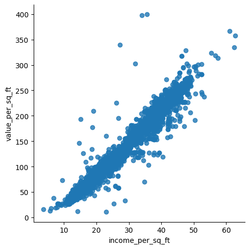

```python
sns.lmplot(y="value_per_sq_ft",x="income_per_sq_ft",data=df,fit_reg=False)
```

## 2. 使用iris.csv数据进行聚类分析：不用variety列，使用前四列数据进行Kmeans聚类分析(k=3)，并使用pca降维后作图显示聚类结果，然后与variety进行比较。

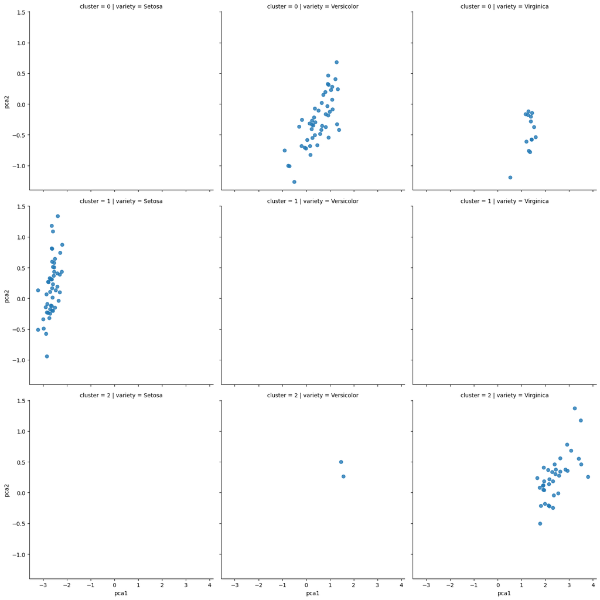

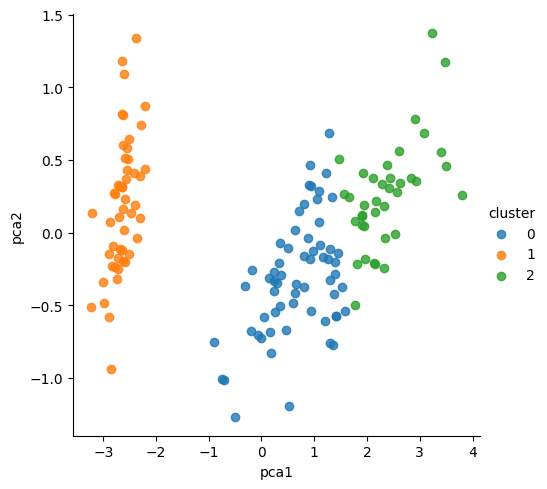

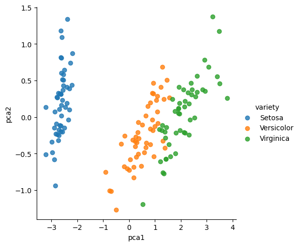

```python
df2tot=pd.read_csv("iris(1).csv")
df2=df2tot.iloc[:,:4]
kmeans=KMeans(n_clusters=3,random_state=42,).fit(df2.values)
kmeanstmp=pd.DataFrame(kmeans.labels_,columns=["cluster"])
pca=PCA(n_components=2).fit(df2)
pca_trans=pca.transform(df2)
pcatrans_df=pd.DataFrame(pca_trans,columns=["pca1","pca2"])
kmeans3=pd.concat([kmeanstmp,pcatrans_df,df2tot["variety"]],axis=1)
sns.lmplot(x="pca1",y="pca2",data=kmeans3,fit_reg=False,row="cluster",col="variety")
sns.lmplot(x="pca1",y="pca2",data=kmeans3,hue="cluster",fit_reg=False)
sns.lmplot(x="pca1",y="pca2",data=kmeans3,hue="variety",fit_reg=False)
```

分面图中第二行和第三行基本上都只有一个子图中有点，聚类模型分类效果很好。不足之处可以从分面图的第一行中看出，Versicolor和Virginica中均有点被分入了cluster0，此处分类效果欠佳。以上结论也可以从下面两个图的对比中看出，Versicolor和Virginica的交界处有面积不大的分类错误的区域。